# Anti Immigration Parties

Adaline Powell

2025-11-26

**Executive Summary:** This study examines whether the electoral success of anti-immigrant parties leads to stricter immigration policies and how ideology and regime type shape this relationship. Using data from the Chapel Hill Expert Survey, the UN World Population Policies dataset, and the Global Party Survey, I analyze whether anti-immigrant parties—defined as those prioritizing immigration issues and advocating for restrictive policies—translate their success into policy outcomes. The results show that both party type and ideology matter, and their impact on immigration policy strictness depends on electoral support. When regime type is included, the overall relationship remains, but some effects weaken, suggesting institutional context plays a meaningful role. Although anti-immigrant parties can influence immigration policy, their effectiveness is conditional on vote share, ideological position, and political environment. Limitations include data inconsistencies, missing values, and regression assumption violations, so findings should be interpreted with caution.

## Introduction

In recent years, the emergence of anti-immigrant parties in various countries has sparked debates about their impact on immigration policies. Fennema (1997) describes these parties as strongly opposing current migration policies and focusing their political agendas on immigration-related issues. He suggests that these parties, often labeled as ‘extreme right,’ tend to advocate for strict immigration restrictions, with mean scores for policy stringency surpassing 8.5 (Lubbers).

In this study, I aim to explore the relationship between the electoral success of anti-immigrant parties and the strictness of anti-migration policies. I will address several key questions:

**Does the electoral success of these parties correspond to an increase in the strictness of immigration laws?**

**How does the left-right orientation of these parties influence their impact on immigration policies?**

**Whether this relationship varies depending on the regime type.**

To define ‘anti-immigration’ parties for this study, I will adopt a similar definition found in existing literature. Parties that advocate for stricter immigration measures and prioritize immigration issues in their political agendas will be classified as ‘anti-immigration.’

Through this study, I aim to contribute to the ongoing discussion by shedding light on the role of anti-immigrant parties in shaping contemporary migration discourse.

## Method

An important consideration for this study is the use of multiple datasets from different years. Finding datasets with all the necessary variables for similar years proved challenging, and extensive data cleaning was required due to differences in party labeling between datasets. Steps were taken to address missing data where possible.

### Studies

This study is divided into two sections, each focusing on answering specific questions:

1. The first section investigates whether anti-immigrant party success correlates with increased strictness in immigration laws and explores whether the left or right orientation of anti-immigrant parties influences this.

-Null Hypothesis (H0):

The strictness of immigration laws does not depend on the electoral success of anti-immigrant parties and the left-right orientation of these parties.

HA: The strictness of immigration laws does depend on the electoral success of anti-immigrant parties and the left-right orientation of these parties.

2. The final section examines whether this relationship is influenced by regime type.

H0: There is no significant difference in the relationship between anti-immigrant party impact on immigration policies and regime type.

HA: The relationship between anti-immigrant party impact on immigration policies and regime type is significantly different.

## Exploratory Analysis

#### Variable Selection

Including controls within these models is crucial for ensuring that the estimated relationship between a party’s anti-immigration stance and the strictness of immigration policies is accurate. Firstly, controlling for parties’ positions on public services helps to account for their broader policy agenda and priorities. Parties advocating for improving public services may have different policy objectives and approaches to governance, which could influence their stance on immigration and ultimately impact policy outcomes compared to the parties who advocate for reducing taxes. Parties advocating for reduced taxes may prioritize economic considerations over social welfare, potentially influencing their approach to immigration policy. Including controls for the party’s stance on corruption is vital as corruption can undermine the effectiveness of immigration policies and erode public trust in government institutions. Parties’ positions on reducing corruption may reflect their commitment to transparency and accountability, which could influence their immigration policy proposals and implementation. Finally, controlling parties’ positions on decision-making reflects their stance on governance and democracy. Parties advocating for greater citizen participation in decision-making may approach immigration policy with a more inclusive and consultative approach, potentially leading to different policy outcomes compared to parties favoring centralized decision-making by elected officials. Overall, including controls for these variables ensures that the estimated relationship between anti-immigration stance and immigration policy strictness is robust and accounts for broader political and policy contexts.

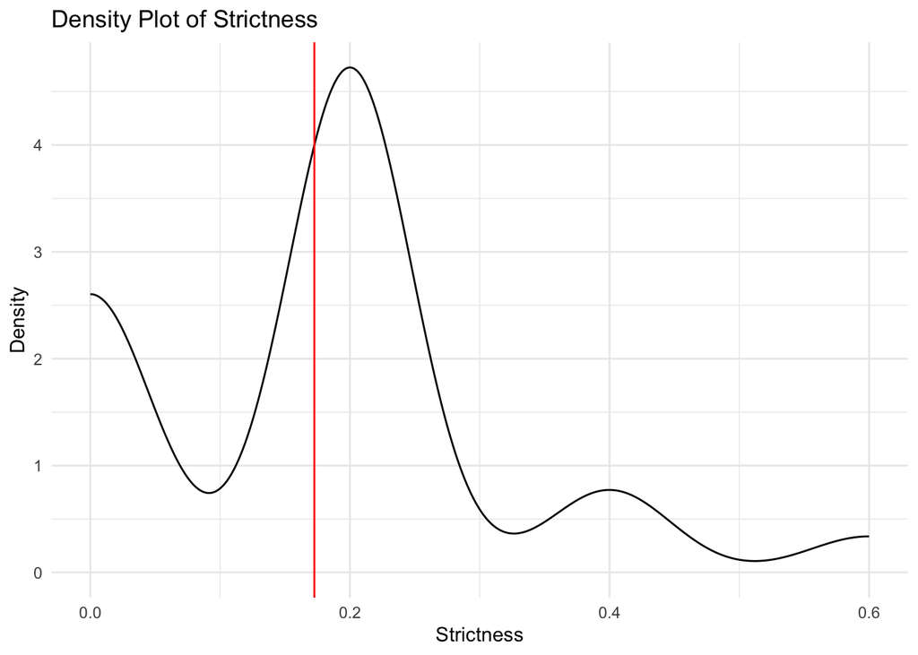

Above displays the distribution of the main dependent variable, assessing the policy strictness regarding immigration. It can be argued, the distribution of this variable may be positively skewed slightly

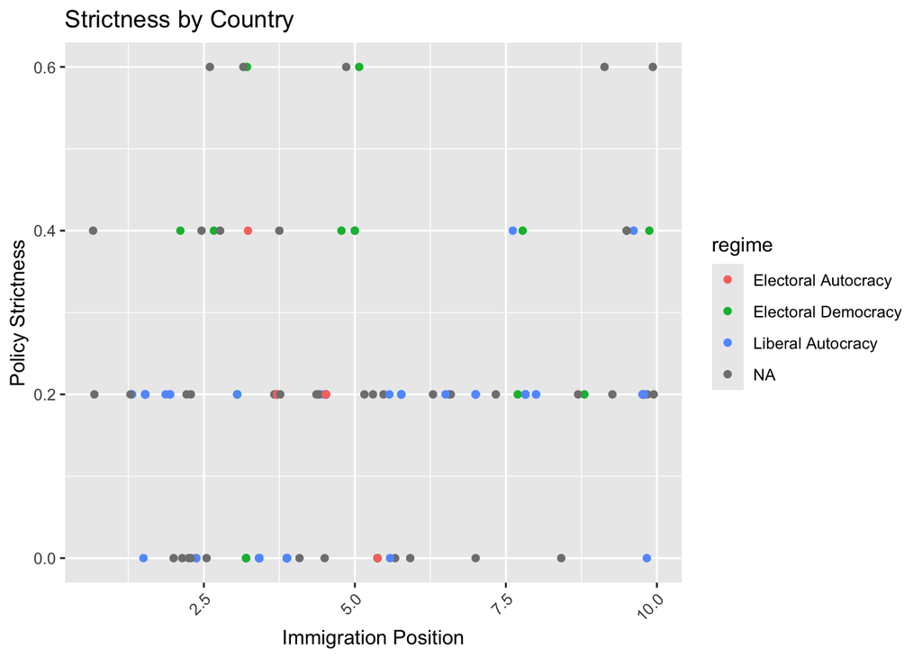

The plot above distinguishes parties’ immigration positions as well as the strictness of policies relating to immigration. Additionally, the plot accounts for regime type. Immigration position appears to have a lot of variance. It appears that liberal autocracies tend to have lower levels of immigration policy strictness compared to electoral democracies and autocracies.

A reason as to why we may see this distrubtion. Electoral democracies often have robust systems of checks and balances, which can moderate policy decisions additionally public opinion and media coverage play significant roles in shaping policy decisions

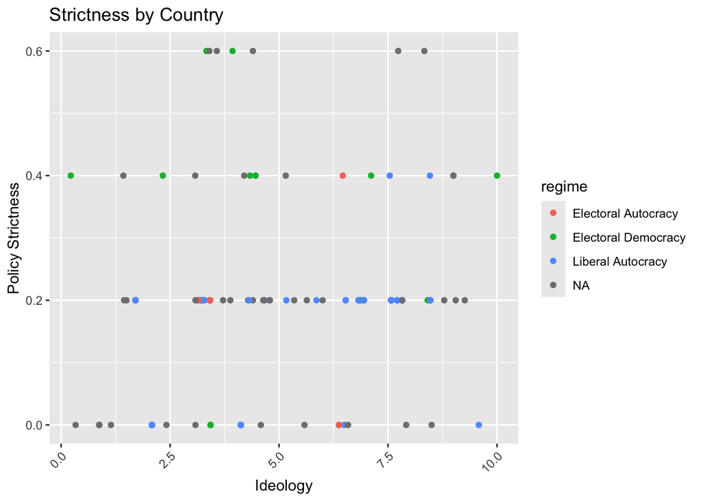

## Studies

### When anti-immigrant parties are electorally successful do immigration laws become more strict? Does the left-right orientation of these parties make a difference in this ability?

In order to answer this question, I will utilize a generalized linear model, including a three-way interaction between the type of party. The percent of vote received as well as the ideology of the party.

By incorporating interaction terms like antipartyVOTES_PERCENTideology, we can explore how the relationship between a party’s anti-immigration stance and policy strictness changes with varying levels of votes (representing electoral support). A three-way interaction examines how these factors jointly influence the outcome variable, which in this case is the strictness of immigration policies. It enables us to understand how the impact of an anti-immigration stance on policy strictness differs based on both the party’s ideological position and its level of electoral support. This is crucial because the effect of an anti-immigration stance on policy strictness may not be consistent across different ideological positions or levels of electoral support.

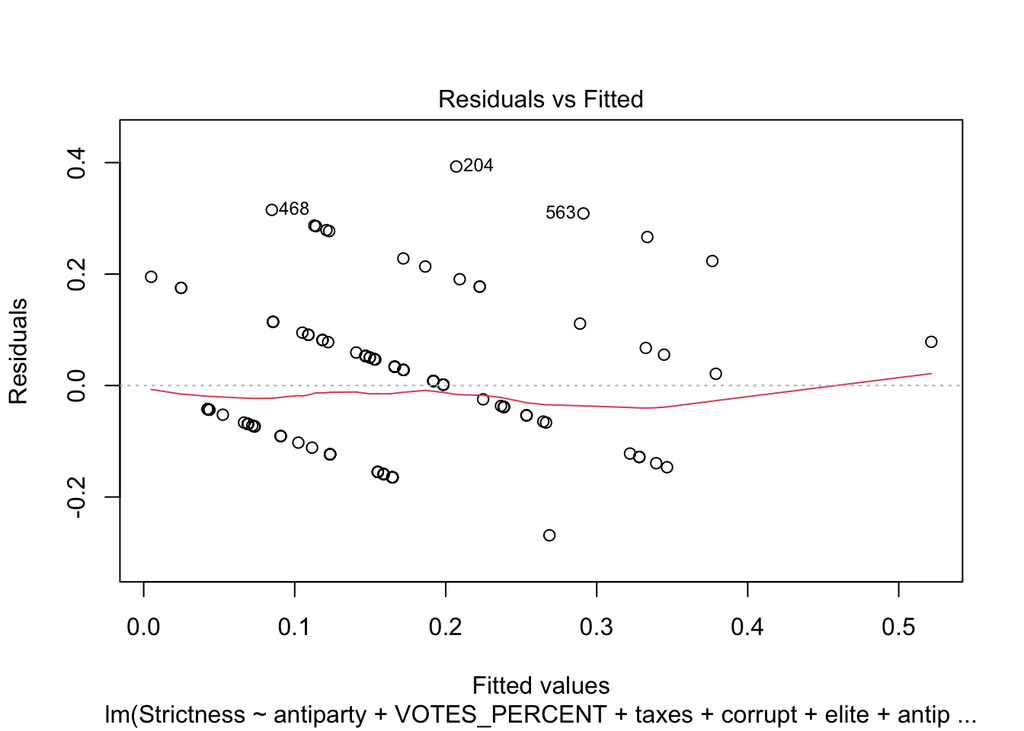

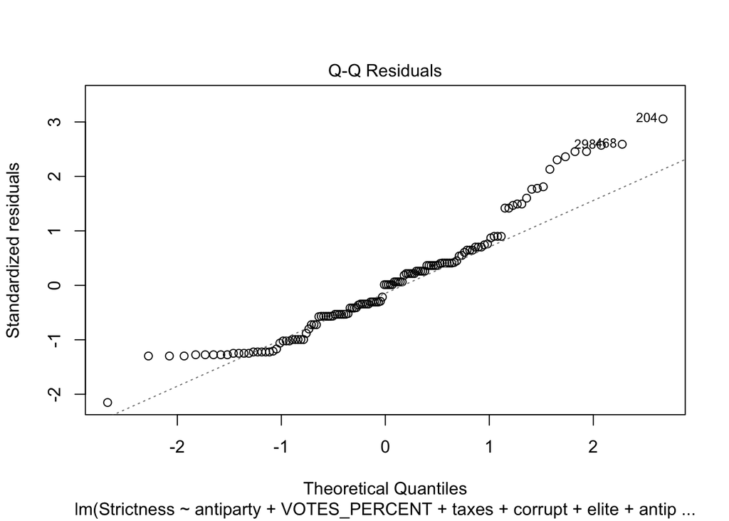

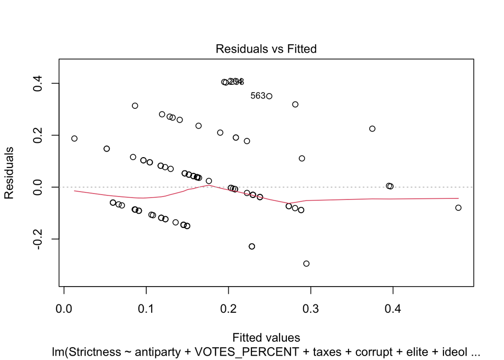

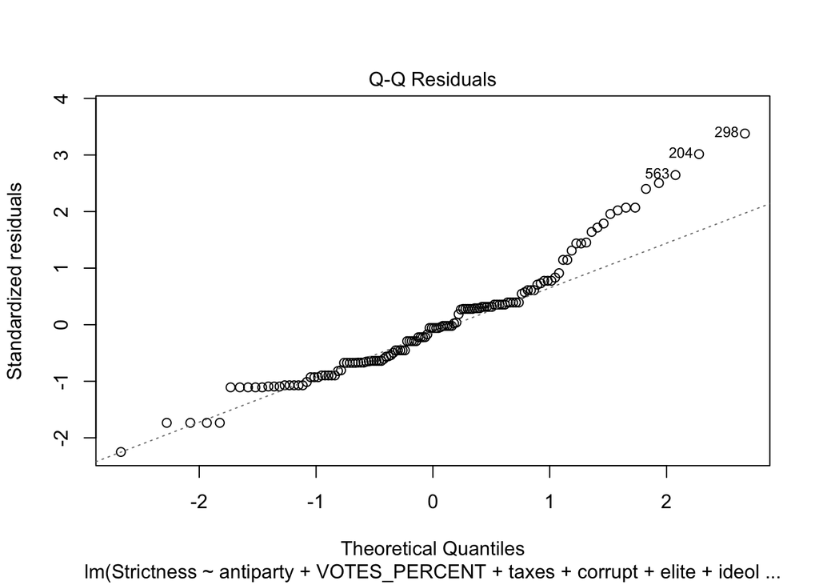

In assessing the assumptions of the generalized linear model, most of them are met besides constant variance. It appears that with both models, there are more points above the dashed line, and there is a slight downward trend. Although the spread across is decent, and most of the points line up with the line in the Q-Q plot. With this in mind, interpretations of the results must be taken with caution.

Table 1

|  | Model 1 |  |  | Model 2 |  |  |
| --- | --- | --- | --- | --- | --- | --- |
| Predictors | Estimates | CI | p | Estimates | CI | p |
| Y-Intercept | 0.16 | -0.01 – 0.33 | 0.146 | 0.73 | 0.38 – 1.08 | <0.001 |
| Party[Not Anti] | -0.04 | -0.16 – 0.08 | 0.524 | -0.68 | -1.05 – -0.31 | 0.002 |
| Vote | 0.00 | -0.00 – 0.00 | 0.495 | -0.04 | -0.06 – -0.01 | 0.011 |
| Taxes | -0.05 | -0.08 – -0.02 | 0.002 | -0.06 | -0.09 – -0.03 | <0.001 |
| Corruption | 0.02 | 0.00 – 0.03 | 0.017 | 0.02 | 0.00 – 0.03 | 0.011 |
| Elite | -0.01 | -0.03 – 0.00 | 0.237 | -0.01 | -0.03 – 0.01 | 0.256 |
| Ideology | 0.04 | 0.02 – 0.07 | 0.003 | -0.03 | -0.07 – 0.02 | 0.256 |
| Party[Not Anti] : Vote | -0.00 | -0.01 – 0.00 | 0.401 | 0.04 | 0.01 – 0.06 | 0.015 |
| Party[Not Anti] : Ideology |  |  |  | 0.10 | 0.04 – 0.16 | 0.007 |
| Vote:Ideology |  |  |  | 0.01 | 0.00 – 0.01 | 0.008 |
| Party[Not Anti] : Vote : Ideology |  |  |  | -0.01 | -0.01 – -0.00 | 0.019 |
| Observations | 132 |  |  | 132 |  |  |
| R<sup>2</sup> / R<sup>2</sup> adjusted | 0.241 / 0.198 |  |  | 0.319 / 0.263 |  |  |

The table above displays the results from both the model with no three-way interaction and the model with the three-way interaction.

Holding all variables constant, when a party is not anti-immigrant, it is associated with lower levels of immigration strictness among the policies (-0.04). However, this effect is not statistically significant. In model two, we observe this effect to be greater as it increases to an effect size of -0.68, which is statistically significant. Regarding ideology, we observe that when a party’s ideology changes, becoming more conservative, there is an increase in levels of immigration strictness among policies (0.04), which is statistically significant. Conversely, we see the opposite effect in model two where levels of strictness decreased by 0.03, although this change is not statistically significant.

Model two includes the interaction between party and ideology. We see that when a party is not anti-immigrants and their ideology becomes more conservative the levels of strictness and immigration policies increases by 0.1 and this is statistically significant.

The question of whether or not the influence of a party being anti-immigrant on policy strictness, depending on success, is answered through the interaction between party and vote in both models. We observe no significant effect, as the estimate is not statistically significant in the first. In model two, however, we see that when a party is not anti-immigrant and vote share increases, levels of strictness increase slightly by 0.04, which is statistically significant.

When a party is not anti-immigrant, while still seeing an increase in vote share and becoming more conservative, we observe that levels of strictness on immigration policy decrease slightly by 0.01, which is statistically significant.

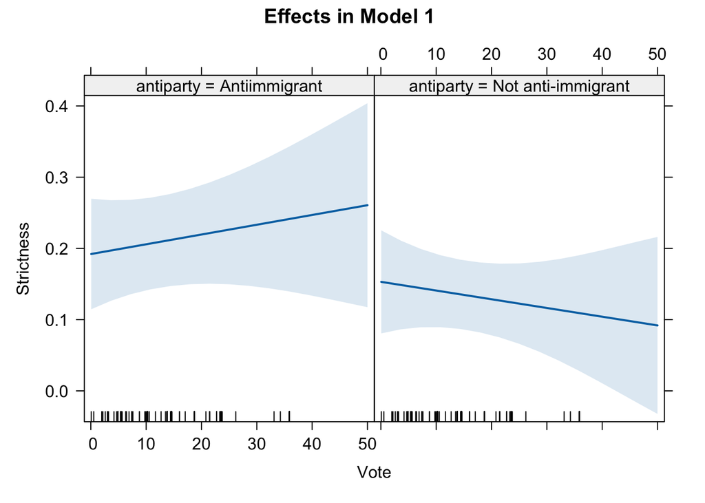

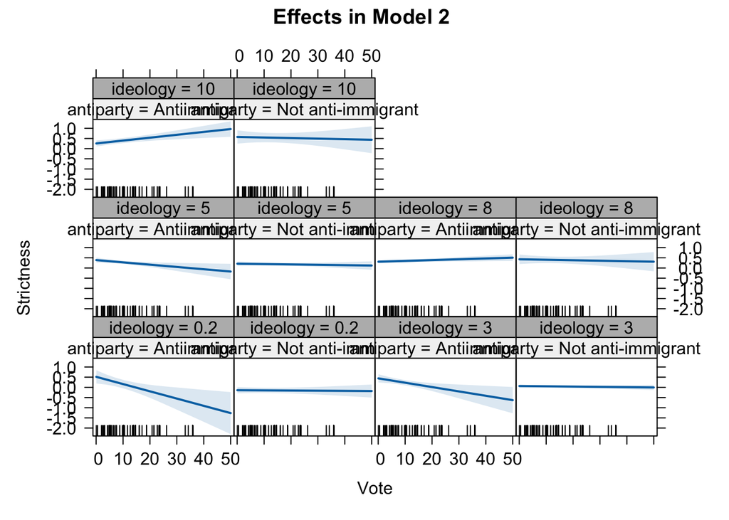

The plots above allows us to visually depict the interaction effects on levels of strictness.

##### Conclusion

It’s intriguing to observe that when the model includes the three-way interaction, there are effects on the coefficients of the variables compared to the first model, excluding the interaction. We notice that some variables gain statistical significance when we include the three-way interactions, such as whether or not the party is anti-immigrant. However, we also see some variables lose statistical significance, like ideology.

There could be several reasons for this effect. Firstly, the importance of the three-way interaction, as it is statistically significant, may alter the effects of the individual variables. Additionally, this could be due to coding issues or multicollinearity between variables, where the inclusion of additional interaction terms changes the relationships between the variables. Further exploration and sensitivity analysis may help clarify the reasons behind these changes in statistical significance.

In summary, we find that the interaction between party and vote is statistically significant. This indicates that whether or not a party is anti-immigrant and their success is crucial for influencing immigration strict policies. Similarly, the interaction between party and ideology is also significant, suggesting that its influence on policy strictness depends on the ideology of the party. The interplay of all three variables is also important in explaining levels of strictness among immigration policies.

### Is this relationship affected by regime type or the type of legislative systems the country has?

##### Assumptions:

The assumptions similar to the assumptions of the previous model utilized in the last study. Although there is not constant variance among the points as we can see a slight downward trend, and the data points are not spread across the plot evenly. Similar to the previous model results of this model should be taking slightly as this may not be the best fit for the data.

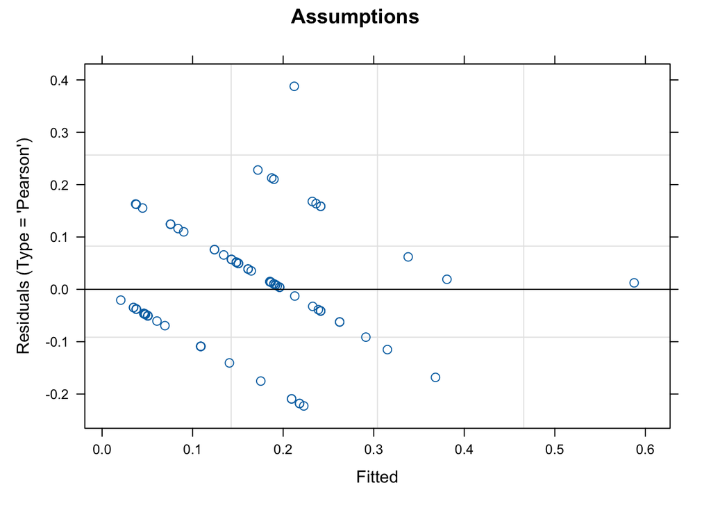

Table 1

[output not shown]

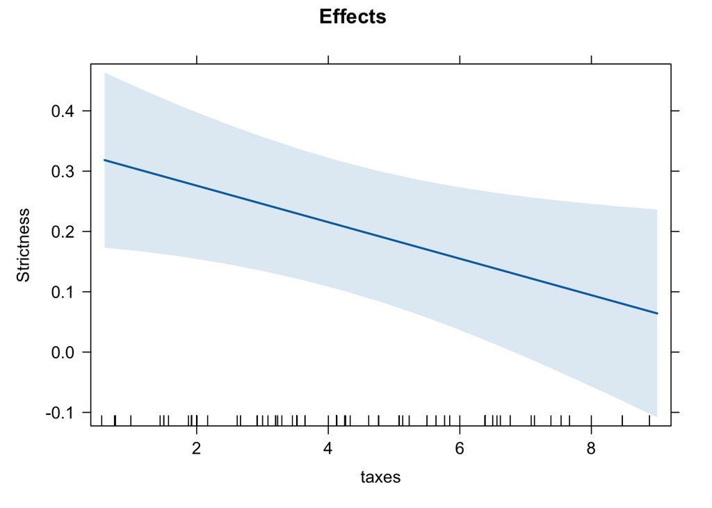

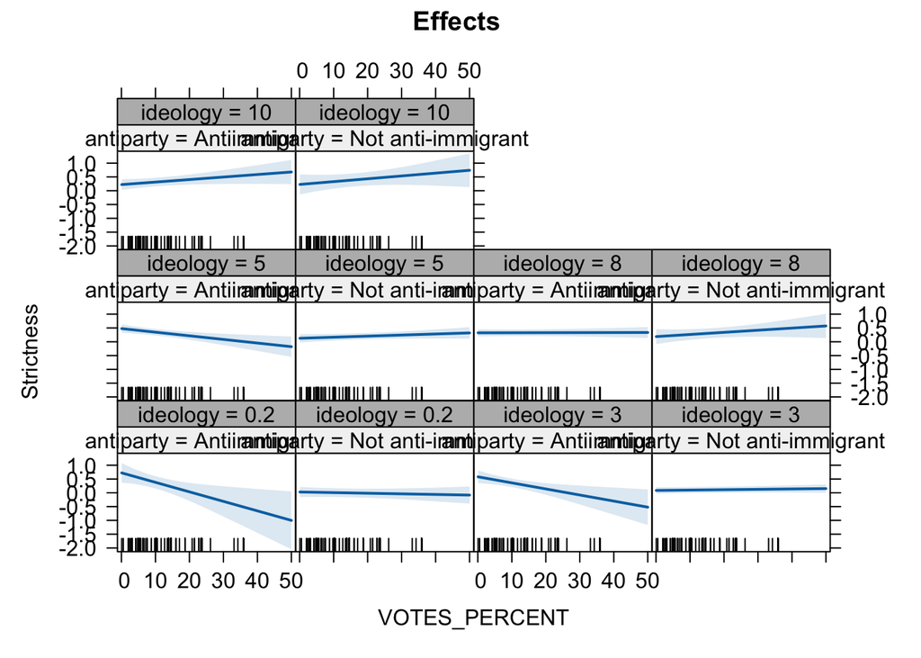

The graphic above provides a visual depiction of the relationship assessed in the model.

## Conclusion

However, when considering a party that is anti-immigrant, their electoral success, and ideology, the impact on levels of strictness of immigration policies is not substantial and is only statistically significant in one model.

Table 1

|  | Model 1 |  |  | Model 2 |  |  | Model 3 |  |  |
| --- | --- | --- | --- | --- | --- | --- | --- | --- | --- |
| Predictors | Estimates | CI | p | Estimates | CI | p | Estimates | CI | p |
| Y-Intercept | 0.16 | -0.01 – 0.33 | 0.146 | 0.73 | 0.38 – 1.08 | <0.001 | 0.84 | 0.47 – 1.20 | <0.001 |
| Party[Not Anti] | -0.04 | -0.16 – 0.08 | 0.524 | -0.68 | -1.05 – -0.31 | 0.002 | -0.71 | -1.09 – -0.33 | 0.002 |
| Vote | 0.00 | -0.00 – 0.00 | 0.495 | -0.04 | -0.06 – -0.01 | 0.011 | -0.04 | -0.06 – -0.01 | 0.038 |
| Taxes | -0.05 | -0.08 – -0.02 | 0.002 | -0.06 | -0.09 – -0.03 | <0.001 | -0.03 | -0.06 – -0.00 | 0.061 |
| Corruption | 0.02 | 0.00 – 0.03 | 0.017 | 0.02 | 0.00 – 0.03 | 0.011 | -0.00 | -0.02 – 0.01 | 0.750 |
| Elite | -0.01 | -0.03 – 0.00 | 0.237 | -0.01 | -0.03 – 0.01 | 0.256 | 0.01 | -0.01 – 0.02 | 0.463 |
| Ideology | 0.04 | 0.02 – 0.07 | 0.003 | -0.03 | -0.07 – 0.02 | 0.256 | -0.05 | -0.10 – -0.00 | 0.063 |
| Party[Not Anti] : Vote | -0.00 | -0.01 – 0.00 | 0.401 | 0.04 | 0.01 – 0.06 | 0.015 | 0.03 | 0.00 – 0.06 | 0.050 |
| Party[Not Anti] : Ideology |  |  |  | 0.10 | 0.04 – 0.16 | 0.007 | 0.07 | 0.00 – 0.14 | 0.061 |
| Vote:Ideology |  |  |  | 0.01 | 0.00 – 0.01 | 0.008 | 0.00 | 0.00 – 0.01 | 0.049 |
| Party[Not Anti] : Vote : Ideology |  |  |  | -0.01 | -0.01 – -0.00 | 0.019 | -0.00 | -0.01 – 0.00 | 0.192 |
| Random Effects |  |  |  |  |  |  |  |  |  |
| σ<sup>2</sup> |  |  |  |  |  |  | 0.01 |  |  |
| τ<sub>00</sub> |  |  |  |  |  |  | 0.01 <sub>regime</sub> |  |  |
| ICC |  |  |  |  |  |  | 0.37 |  |  |
| N |  |  |  |  |  |  | 3 <sub>regime</sub> |  |  |
| Observations | 132 |  |  | 132 |  |  | 110 |  |  |
| R<sup>2</sup> / R<sup>2</sup> adjusted | 0.241 / 0.198 |  |  | 0.319 / 0.263 |  |  | 0.259 / 0.530 |  |  |

I believe it’s important to observe the development of each model as we add certain variables, as well as control for clustering and other important considerations. The table includes all three models, allowing us to see the evolution of each model and whether coefficients change or remain the same.

### Discusion

The results observed can be attributed to specific contextual factors. Economic conditions may exert influence on various variables, including employment rates, the labor market, and overall income inequality in the regions associated with each party. Additionally, historical experiences of parties with immigration or the region’s migration patterns could impact the levels of strictness observed. Demographic compositions might have influenced the analysis, particularly in regions where a party may be more diverse compared to others, as well as factors related to popularity and voter preferences. Future research should include levels of unemployment as a lot of literature suggest that immigration and unemployment can go hand-in-hand

There are multiple caveats to this study that are important to make note of. the first is the uncertainty with the data collection stage as well as the data cleaning and combination. As mentioned before data was utilized from three different sources and I needed to go through and clean up party name and party abbreviation to be able to match up all day sets. Errors may have been performed this analysis. Additionally, assumptions for a linear regression violated, so it is important to take the results with caution.

#### Missingness

Due to the extensive data cleaning process, a select number of parties were chosen for analysis to ensure completeness of results. Efforts were made to ensure that these parties consistently had values across all utilized datasets. However, there are some missing values, particularly in perception and regime type variables, likely due to inaccessible information in the datasets. Missingness, especially in vote percentages, may be attributed to the combined nature of the datasets. Some datasets may lack vote percentages for specific parties while containing other relevant variables. To address this, Miss Forest imputation could have been considered appropriate as it can utilize available values within the dataset to predict missing values. Because of the fragility of the new data itself, concerns for over fitting, I avoided imputing any missing results.

##### References

-Norris, Pippa. 2020. “Global Party Survey, 2019.” doi:10.7910/DVN/WMGTNS. “Some Conceptual Issues and Problems in the Comparison of Anti-Immigrant Parties in Western Europe - Meindert Fennema, 1997.” https://journals.sagepub.com/doi/abs/10.1177/1354068897003004002 (May 14, 2024).

-Spanje, Joost van. 2011. “The Wrong and the Right: A Comparative Analysis of ‘Anti-Immigration’ and ‘Far Right’ Parties.” Government and Opposition 46(3): 293–320. doi:10.1111/j.1477-7053.2011.01340.x.

-Van Der Brug, Wouter, Meindert Fennema, and Jean Tillie. 2005. “Why Some Anti-Immigrant Parties Fail and Others Succeed: A Two-Step Model of Aggregate Electoral Support.” Comparative Political Studies 38(5): 537–73. doi:10.1177/0010414004273928.

-“World Population Prospects - Population Division - United Nations.” https://population.un.org/wpp/Download/Standard/CSV/ (May 14, 2024).